# Skilaverkefni 1

Atli Snaer Kristjansson, Valdimar Orn Sverrisson

1/17/2022

```r
knitr::opts_chunk$set(echo = TRUE)
library(tidyverse)
library(readr)
library(dplyr)
library(lubridate) # pakki med follum fyrir vinnslu med dagsetningar (date eda datetime breytur)
library(ggplot2)
```

## a)

Endurnefning dálka yfir í viðeigandi nöfn. Ákveðið var að sleppa öllum séríslenskum stöfum úr nöfnum þeirra til að koma í veg fyrir vesen í forritun og nota camel case í nöfnunum.

```r
litir <- c("#f24236","#00a6fb") # skilgreining á litum sem verða notaðir í öllum gröfum í verkefninu
AV <- read.csv("./data/vedurgogn.csv")
AV <- rename(AV
, stod = stöð
, ar = ár
, man = mán
, medalHiti = t
, medalMaxHiti= tx
, maxHiti = txx
, dagsetningMaxHita = txxD1
, medalMinHiti = tn
, minHiti = tnn
, dagsetningMinHita = tnnD1
, medalRakastig = rh
, heildarUrkoma = r
, maxSolahringsUrkoma = rx
, dagsetningMaxSolahringsUrkoma = rxD1
, medalThristingur = p
, medalSkyjahula = n
, solskinsStundir = sun
, medalVindhradi = f )
```

## b)

Við skoðuðum tög allra dálkanna og ákváðum að öll tögin væru viðeigandi, hægt væri að breyta ar, man og dagsettninga dálkunum í datetime en það tæki eflaust töluvert meira pláss og tíma frá tölvunni svo að hagkvæmast væri að geyma þetta bara sem int.

```r
AV %>%
  glimpse()
```

```
## Rows: 1,702
## Columns: 18
## $ stod                          <int> 1, 1, 1, 1, 1, 1, 1, 1, 1, 1, 1, 1, 1, 1…
## $ ar                            <int> 1949, 1949, 1949, 1949, 1949, 1949, 1949…
## $ man                           <int> 1, 2, 3, 4, 5, 6, 7, 8, 9, 10, 11, 12, 1…
## $ medalHiti                     <dbl> -2.7, 0.0, 0.1, 0.0, 3.6, 9.8, 10.5, 10.…
## $ medalMaxHiti                  <dbl> 0.5, 2.5, 2.8, 3.1, 7.2, 13.0, 13.2, 13.…
## $ maxHiti                       <dbl> 6.6, 7.8, 7.4, 6.6, 13.0, 20.4, 17.1, 16…
## $ dagsetningMaxHita             <int> 9, 6, 4, 2, 22, 22, 28, 18, 2, 11, 2, 31…
## $ medalMinHiti                  <dbl> -6.8, -2.5, -2.9, -2.9, 0.3, 6.7, 8.7, 7…
## $ minHiti                       <dbl> -15.2, -7.5, -14.3, -8.9, -5.0, 1.6, 6.0…
## $ dagsetningMinHita             <int> 12, 27, 14, 21, 5, 7, 4, 9, 9, 25, 13, 9…
## $ medalRakastig                 <int> 81, 87, 86, 77, 70, 76, 86, 80, 87, 81, …
## $ heildarUrkoma                 <dbl> 68.8, 80.0, 58.7, 51.8, 27.9, 44.2, 66.0…
## $ maxSolahringsUrkoma           <dbl> 9.6, 8.3, 8.4, 17.8, 5.5, 13.2, 12.6, 25…
## $ dagsetningMaxSolahringsUrkoma <int> 25, 16, 5, 18, 12, 30, 6, 29, 29, 2, 1, …
## $ medalThristingur              <dbl> 996.7, 989.0, 1010.4, 1000.2, 1014.8, 10…
## $ medalSkyjahula                <dbl> 6.0, 6.7, 5.9, 5.8, 5.1, 5.7, 7.2, 6.1, …
## $ solskinsStundir               <dbl> 18.1, 25.1, 106.6, 134.7, 243.2, 187.3, …
## $ medalVindhradi                <dbl> 8.5, 9.2, 5.9, 7.4, 6.9, 5.9, 4.1, 4.7, …
```

## c)

Solskinsstundir voru með 21 NA’s sem að við fjarlaegðum MedalRakastig, medalMaxHitiPerAr,maxHitiPerMan og dagsettningMaxHita voru hver með 1 NA’s í sér sem að við fjarlægðum

```r
AV <- na.omit(AV)
```

Hér bætum við við árstíðar dálki sem að er af factor tagi. Ekki er skráð ársmælingaraðirnar á árstíð.

```r
AV <-  mutate(AV,
              arstid = recode_factor(
                man,
               `12`= "Vetur", `1` = "Vetur",`2` = "Vetur",
               `3` = "Vor",`4` = "Vor",`5` = "Vor",
               `6` = "Sumar",`7` = "Sumar",`8` = "Sumar",
               `9` = "Haust",`10` = "Haust",`11` = "Haust"
                )
              )
```

## d)

Hér er bætt við sér dálk með borg þar sem mælingin átti stað þ.e.a.s annaðhvort Akureyri eða Reykjavík. Þessi dálkur verður mikið notaður í gröfunum hér að neðan.

```r
AV <- mutate(AV,
             stadur = recode_factor(
               stod,
               `1` = "Reykjavik",
               `422` = "Akureyri"
             )
)
```

#### Dæmi:

Teiknið mynd sem sýnir heildarfjölda sólskinsstunda fyrir Reykjavík og Akureyri. Segið frá í samfelldu máli hvaða ályktun þið dragið út frá myndinni.

#### Lausn:

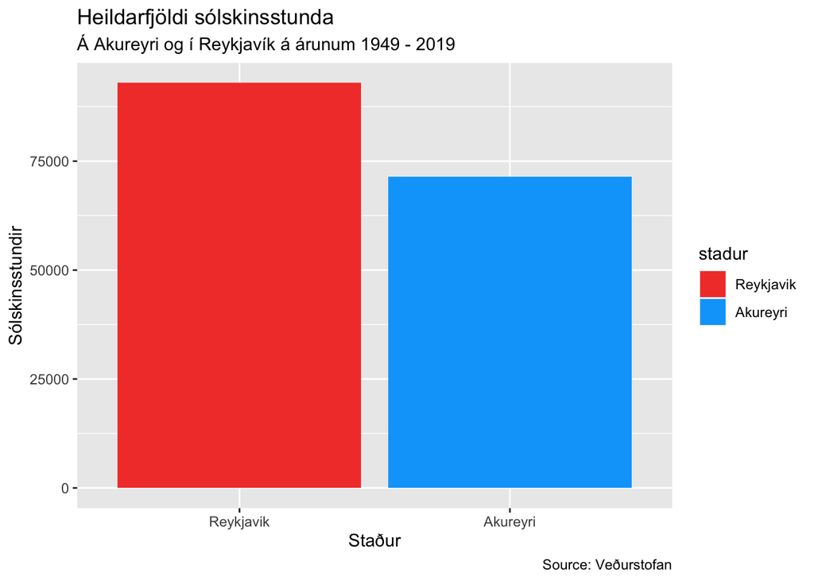

```r
ggplot(AV, aes(x = stadur, y = solskinsStundir, fill = stadur)) +
  geom_bar(stat="Identity") +
  scale_fill_manual(values=litir) +
  labs(title="Heildarfjöldi sólskinsstunda",
       subtitle="Á Akureyri og í Reykjavík á árunum 1949 - 2019",
       y="Sólskinsstundir",
       x="Staður",
       caption = "Source: Veðurstofan")
```

#### Dæmi:

Teiknið mynd sem sem lýsir dreifingu fjölda sólskinsstunda fyrir Reykjavík og Akureyri. Segið frá í samfelldu máli hvaða ályktun þið dragið út frá myndinni.

#### Lausn:

Hérna er myndin okkar

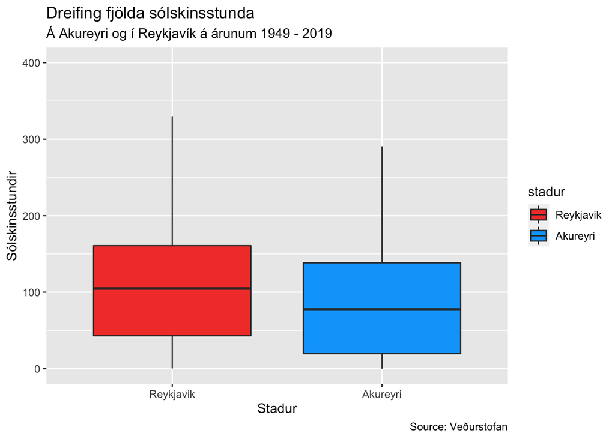

```r
ggplot(AV, aes(x = stadur, y = solskinsStundir, fill = stadur)) +
  geom_boxplot() +
  scale_fill_manual(values=litir) +
  ylim(c(0,400)) +
  labs(title="Dreifing fjölda sólskinsstunda",
       subtitle="Á Akureyri og í Reykjavík á árunum 1949 - 2019",
       y="Sólskinsstundir",
       x="Stadur",
       caption = "Source: Veðurstofan")
```

#### Dæmi:

Teiknið mynd sem sýnir sýnir heildarfjölda sólskinsstunda eftir árstíð fyrir Reykjavík og Akureyri. Segið frá í samfelldu máli hvaða ályktun þið dragið út frá myndinni.

#### Lausn:

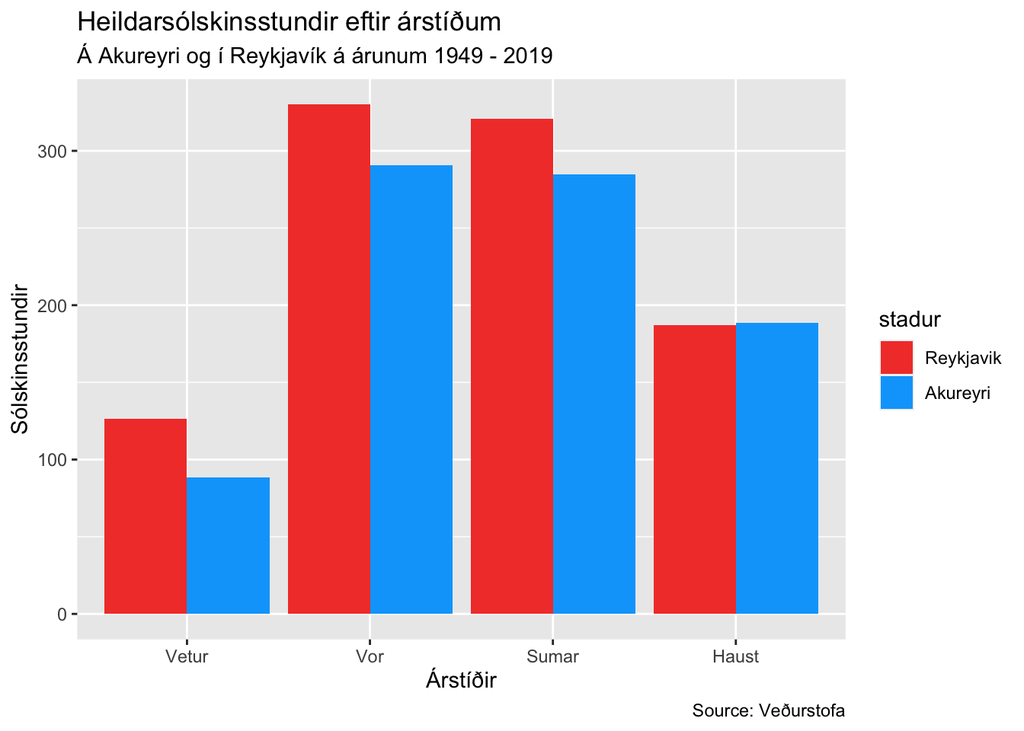

```r
ggplot(data = AV) +
  geom_bar(mapping = aes(x = arstid, y = solskinsStundir, fill = stadur)
           , stat ="identity"
           , position = "dodge") +
  scale_fill_manual(values=litir) +
  labs(subtitle="Á Akureyri og í Reykjavík á árunum 1949 - 2019",
       y="Sólskinsstundir",
       x="Árstíðir",
       title="Heildarsólskinsstundir eftir árstíðum",
       caption = "Source: Veðurstofa")
```

## e)

#### Dæmi:

Teiknið mynd sem sýnir dreifingu mánaðarlegs meðalhita eftir árstíð fyrir Reykjavík og Akureyri. Segið frá í samfelldu máli hvaða ályktun þið dragið út frá myndinni.

#### Lausn:

Hér er dreifing mánaðarlegs meðalhita eftir árstíð fyrir staðina tvo.

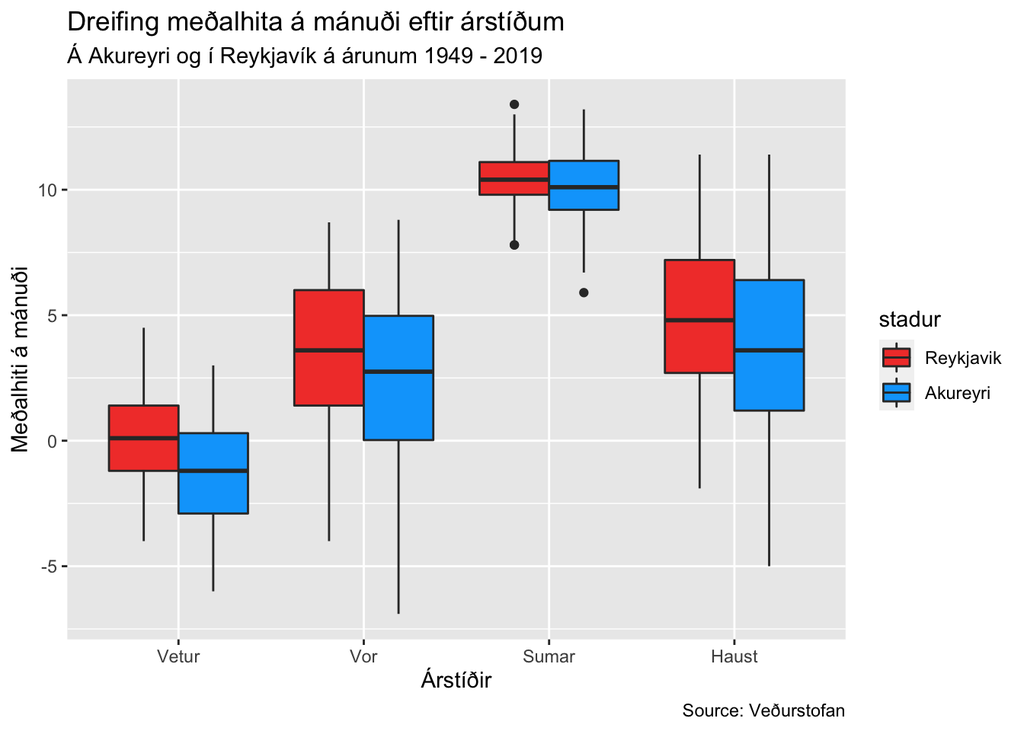

```r
ggplot(AV, aes(x = arstid, y = medalHiti, fill = stadur)) +
  geom_boxplot(shape=21, position = "dodge",
             aes(fill = factor(stadur))) +
  scale_fill_manual(values=litir) +
  labs(title="Dreifing meðalhita á mánuði eftir árstíðum",
       subtitle="Á Akureyri og í Reykjavík á árunum 1949 - 2019",
       y="Meðalhiti á mánuði",
       x="Árstíðir",
       caption = "Source: Veðurstofan")
```

#### Dæmi:

Teiknið mynd sem sýnir dreifingu fjölda mánaðarlegra sólskinsstunda eftir árstíð fyrir Reykjavík og Akureyri. Segið frá í samfelldu máli hvaða ályktun þið dragið út frá myndinni.

#### Lausn:

Hérna er dreifing fjölda mánaðarlegra sólskinsstunda eftir árstíð fyrir staðina tvo.

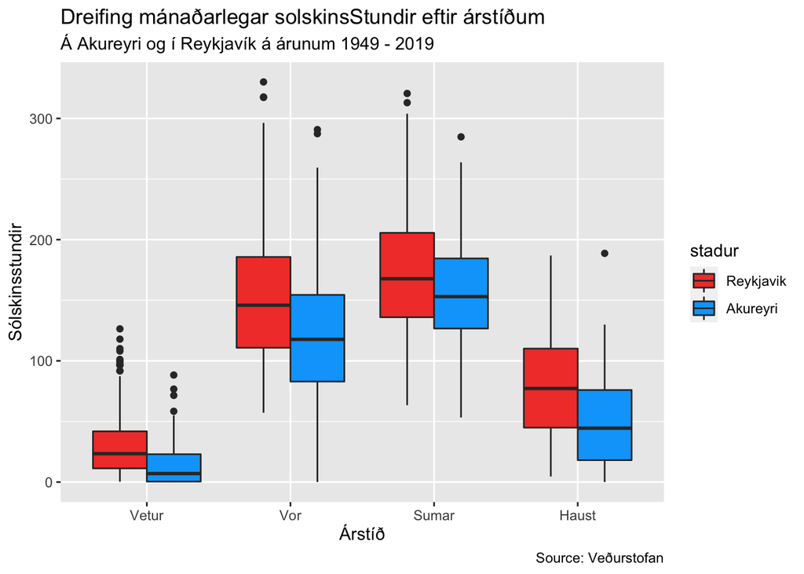

```r
ggplot(AV, aes(x = arstid, y = solskinsStundir, fill = stadur)) +
  geom_boxplot(shape=21, position = "dodge",
               aes(fill = factor(stadur))) +
  scale_fill_manual(values=litir) +
  labs(title="Dreifing mánaðarlegar solskinsStundir eftir árstíðum",
       subtitle="Á Akureyri og í Reykjavík á árunum 1949 - 2019",
       y="Sólskinsstundir",
       x="Árstíð",
       caption = "Source: Veðurstofan")
```

Út frá þessu grafi sést að það er talsverð fylgni í fjölda sólstunda eftir árstíðum á stöðunum tveim en Reykjavík fær talsvert fleirri sólstundir að meðaltali.

#### Dæmi:

Teiknið mynd sem sýnir dreifingu mánaðarúrkomu eftir árstíð fyrir Reykjavík og Akureyri. Segið frá í samfelldu máli hvaða ályktun þið dragið út frá myndinni. Hvernig passar þessi niðurstaða við fjölda sólskinsstunda eftir árstíð á þessum stöðum og hvernig má útskýra það?

#### Lausn

Hérna er dreifing á mánaðarúrkomu eftir árstíðum á stöðunum tveimur

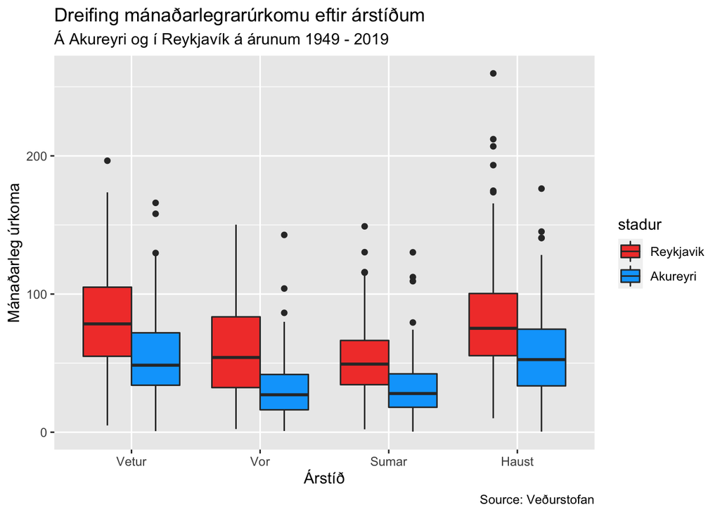

```r
ggplot(AV, aes(x = arstid, y = heildarUrkoma, fill = stadur)) +
  geom_boxplot(shape=21, position = "dodge",
               aes(fill = factor(stadur))) +
  scale_fill_manual(values=litir) +
  labs(title="Dreifing mánaðarlegrarúrkomu eftir árstíðum",
       subtitle="Á Akureyri og í Reykjavík á árunum 1949 - 2019",
       y="Mánaðarleg úrkoma",
       x="Árstíð",
       caption = "Source: Veðurstofan")
```

Reykjavík er að meðaltali með talsvert meiri úrkomu en Akureyri allt árið um kring og stendur það á þver við sólskinsstundirnar þar sem meira sólskin ætti að þýða minni úrkoma.

## f)

#### Dæmi:

Teiknið mynd sem lýsir sambandi mánaðarúrkomu og meðalloftþrýstings. Segið frá í samfelldu máli hvaða ályktun þið dragið út frá myndinni.

#### Lausn:

Höfum hér teiknað graf af sambandi heildar mánaðarúrkomu og meðal loftþrýstingi í hverjum mánuði frá árunum 1949 til 2019. Auk þess teiknum við bestu línu í gegnum grafið. Þessar mælingar eru bland af þeim frá Akureyri og Reykjavík.

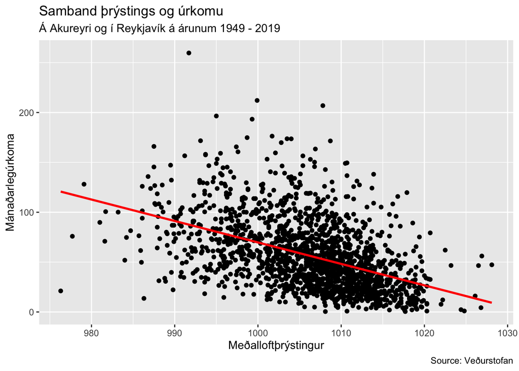

```r
ggplot(AV, aes(x = medalThristingur, y = heildarUrkoma)) +
  geom_point() +
  geom_smooth(color = "red", method = 'lm',se=F) +
  labs(title="Samband þrýstings og úrkomu",
       subtitle="Á Akureyri og í Reykjavík á árunum 1949 - 2019",
       y="Mánaðarlegúrkoma",
       x="Meðalloftþrýstingur",
       caption = "Source: Veðurstofan")
```

Sjáum að það er klárlega samband hér en að staðalfrávikið frá bestu línu sé frekar stórt. Við getum hinsvegar ályktað að hærri meðalloftþrýstingur í mánuði leiðir nokkuð sterklega til minni lægri úrkomu í þeim mánuði og öfugt, eða að lærri loftþrýstingur bendi til þess að úrkoman verði meiri. Það eru hinsvegar fleirri faldir þættir í þessu sambandi sem að valda þessu háa staðalfráviki

## g)

Þetta eru gögn á bilinu 1949 til 2019

```r
G1 <- select(AV, man,ar)
G1 <- AV %>%
  select(man,arstid, solskinsStundir, heildarUrkoma, medalVindhradi)
glimpse(G1)
```

```
## Rows: 1,679
## Columns: 5
## $ man             <int> 1, 2, 3, 4, 5, 6, 7, 8, 9, 10, 11, 12, 1, 2, 3, 4, 5, …
## $ arstid          <fct> Vetur, Vetur, Vor, Vor, Vor, Sumar, Sumar, Sumar, Haus…
## $ solskinsStundir <dbl> 18.1, 25.1, 106.6, 134.7, 243.2, 187.3, 83.1, 160.8, 5…
## $ heildarUrkoma   <dbl> 68.8, 80.0, 58.7, 51.8, 27.9, 44.2, 66.0, 96.0, 97.9, …
## $ medalVindhradi  <dbl> 8.5, 9.2, 5.9, 7.4, 6.9, 5.9, 4.1, 4.7, 5.7, 4.4, 5.7,…
```

```r
G1 %>%
  group_by(arstid) %>%
  summarise(avgVindhradi = mean(medalVindhradi),
            sfVindhrada = sd(medalVindhradi),
            avgUrkomaPerMan = mean(heildarUrkoma),
            sfUrkomu = sd(heildarUrkoma),
            avgSolskinsstundir = mean(solskinsStundir, na.rm = TRUE),
            sfSolskinsstundir = sd(solskinsStundir, na.rm = TRUE)
            ) %>%
  knitr::kable()
```

| arstid | avgVindhradi | sfVindhrada | avgUrkomaPerMan | sfUrkomu | avgSolskinsstundir | sfSolskinsstundir |
| --- | --- | --- | --- | --- | --- | --- |
| Vetur | 5.234699 | 1.726324 | 68.28120 | 36.33044 | 22.81542 | 23.76973 |
| Vor | 4.797613 | 1.507142 | 46.34821 | 31.81045 | 138.21384 | 55.40462 |
| Sumar | 4.102830 | 1.098416 | 42.15401 | 24.70283 | 163.50377 | 48.40260 |
| Haust | 4.566746 | 1.473427 | 68.12969 | 36.83514 | 65.58005 | 41.47439 |

:)

## h)

Reiknið sameiginlegt meðaltal fjölda sólskinsstunda í Reykjavík og Akureyri. Finnið svo í hversu mörgum mánuðum fjöldi sólskinsstunda fór yfir meðaltalið í Reykjavík annars vegar og Akureyri hins vegar.

```r
H <- AV %>%
  select(man, solskinsStundir, stadur) %>%
  na.omit()


avg <- mean(H$solskinsStundir, na.rm = TRUE)
print(avg)
```

```
## [1] 97.86468
```

```r
H %>%
  group_by(stadur) %>%
  summarise(fjoldi = length(which(H$solskinsStundir > 90))) %>%
  knitr::kable()
```

| stadur | fjoldi |
| --- | --- |
| Reykjavik | 857 |
| Akureyri | 857 |

## i)

Finnið í gögnunum og tilgreinið mestu sólarhringsúrkomu í Reykjavík og samsvarandi dagsetningu og einnig fyrir Akureyri

```r
AV %>%
  group_by(stadur) %>%
  summarise(maxUrkoma = max(maxSolahringsUrkoma),
            artal = AV[which.max(AV$maxSolahringsUrkoma),"ar"],
            manudur = AV[which.max(AV$maxSolahringsUrkoma),"man"],
            dagur = AV[which.max(AV$maxSolahringsUrkoma),"dagsetningMaxSolahringsUrkoma"]
            )%>%
  knitr::kable()
```

| stadur | maxUrkoma | artal | manudur | dagur |
| --- | --- | --- | --- | --- |
| Reykjavik | 54.6 | 2012 | 12 | 29 |
| Akureyri | 52.0 | 2012 | 12 | 29 |

## Upp á gaman

Hérna er samanburður á vindhraðamælingum

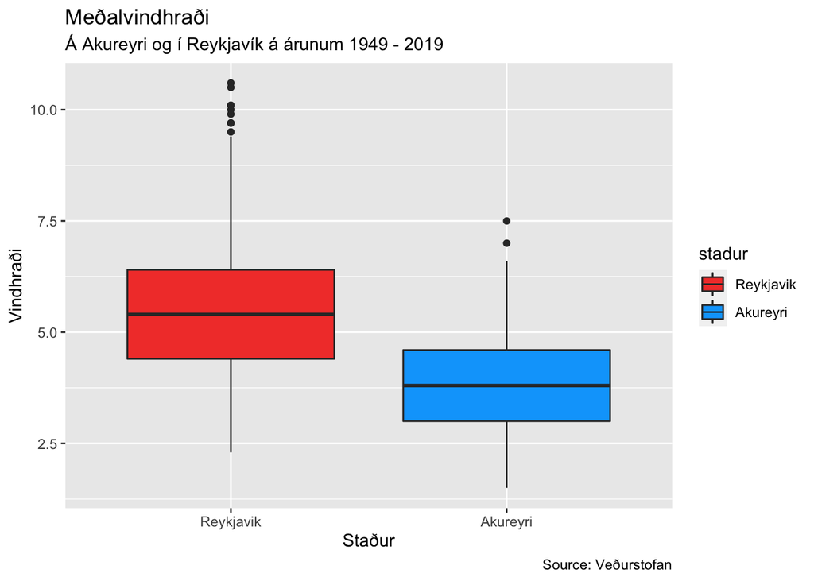

```r
ggplot(AV, aes(x = stadur, y = medalVindhradi, fill= stadur)) +
  geom_boxplot() +
  scale_fill_manual(values=litir) +
  labs(title="Meðalvindhraði",
       subtitle="Á Akureyri og í Reykjavík á árunum 1949 - 2019",
       y="Vindhraði",
       x="Staður",
       caption = "Source: Veðurstofan")
```

Út frá þessu grafi sést að Akureyringar mega eiga það blæs ekki mikið hjá þeim þanna að norðan. Þetta er eflaust vegna þess að Akureyri er í fyrði sem að hlífir þeim frá austan og vestanáttunum.